# Surrogate Marker Evaluation: A Tutorial Using R

Layla Parast

# Introduction

This is an R markdown file (extension is .Rmd) or html of the markdown (extension is .html) to accompany “Surrogate Marker Evaluation: A Tutorial Using R” by Layla Parast, in Statistics in Medicine (2025), 44(10-12):e70048. The tutorial covers the following packages: `Rsurrogate`, `hetsurr`, `OptimalSurrogate`, and `SurrogateParadoxTest`. You can find more information about this paper and tutorial [here](https://github.com/laylaparast/SIMtutorial), the `Rsurrogate` package more generally [here](https://github.com/laylaparast/Rsurrogate), the `hetsurr` package more generally [here](https://github.com/laylaparast/hetsurr), the `OptimalSurrogate` package more generally [here](https://github.com/celehs/OptimalSurrogate), and the `SurrogateParadoxTest` package more generally [here](https://github.com/emily13hsiao/SurrogateParadoxTest). The purpose of the tutorial is to walk through examples of surrogate evaluation. If you have any trouble with this code, file, or packages, please email me at parast@austin.utexas.edu and I will help you. To run this markdown, it is recommended that you have R Version 4.4.0 or higher.

If you are familiar with R markdowns and R in general, you can skip the rest of this section. If you are viewing this as an html file, then this means you are looking at a “knitted” version of the .Rmd file. If you want to see the .Rmd file, you will need to open it using RStudio. If you do not have RStudio, you can download and install it for free at https://posit.co/downloads/. You will also need to download and install R, available for free at https://cran.r-project.org. Now that you have R and RStudio, download the .Rmd file and open it in RStudio. In the top left corner, click “Visual” if it is not already clicked. This will show you a nicely formatted version of the file. Every chunk of R code is shown in a grey box. To run a single box of R code, click the small green right-pointing arrow in the top right corner of the box. To run all the code above the current grey box you care about, click the small grey down-pointing arrow with a green line below it, also in the top right corner. You will only see these arrows if you are viewing the .Rmd file; they do not appear in the .html file. In this file, a code chunk is often dependent on code chunks that precede it, so if you do not run it sequentially, you may get an error.

The process of going from the .Rmd file to an html file is called “knitting”. To knit a file, press the button in the top center of the screen that says “Knit” and has a picture of a ball of yarn and needle. This will run all the R code in the .Rmd and make a nice html file. Notably, for this file, it will take several minutes because there are many computationally intensive bits of code. The way R works is that anyone can make a “package” that implements a method or procedure with R code and make it available to users. To use the package, you must “install” it and “load” it. You only need to install a package one time on your computer; installation is shown in the following section. To load a package you use the function **library()** and this must be done every time you open R/RStudio and want to use the package. You can think of it as telling RStudio - I am about to use some functions in this package, please make them available to me right now. Comments are written within coding chunks by putting a # before them. This tells R that the text is not code, and not to run it. Comments are added to code to help the user understand what the code is doing. If there is code you do not want to run, you can comment it out by putting a # in front of it, and then it will not run.

# Install packages

You will need to install the packages below before you run anything else or try to knit this file; that is, press the small green right-pointing arrow in the top right corner of the box. The **SurrogateParadoxTest** package involves C++ implementation; if you are on a Mac and see error messages about a fortran compiler, please see: https://cran.r-project.org/bin/macosx/tools/

```r
# install the packages from CRAN this code will not run
# when the file is knit; you need to run this code before
# knitting
install.packages("Rsurrogate")
install.packages("hetsurr")
install.packages("OptimalSurrogate")
install.packages("SurrogateParadoxTest")
```

# Proportion of Treatment Effect Explained (Section 3)

This code matches the code in the main text of the paper, available [here](https://github.com/laylaparast/SIMtutorial) and uses the **R.s.estimate** function in the **Rsurrogate** package.

```r
# load the R package
library(Rsurrogate)

# take a look at the data
data(d_example)
names(d_example)
```

```
## [1] "s1.a" "s1.b" "s1.c" "y1"   "s0.a" "s0.b" "s0.c" "y0"
```

```r
# Estimate PTE using the Freedman approach
R.s.estimate(sone = d_example$s1.a, szero = d_example$s0.a, yone = d_example$y1,
    yzero = d_example$y0, type = "freedman")
```

```
## $R.s
## [1] 0.2161019
```

```r
# ask for variance and confidence intervals set.seed(1)
R.s.estimate(sone = d_example$s1.a, szero = d_example$s0.a, yone = d_example$y1,
    yzero = d_example$y0, type = "freedman", var = TRUE, conf.int = TRUE)
```

```
## $R.s
## [1] 0.2161019
##
## $R.s.var
## [1] 0.0005112062
##
## $conf.int.normal.R.s
## [1] 0.1717866 0.2604172
##
## $conf.int.quantile.R.s
## [1] 0.1681863 0.2601535
##
## $conf.int.fieller.R.s
## [1] 0.1679484 0.2620756
```

This code estimates the PTE using the Wang and Taylor approach.

```r
# Estimate the PTE using Wang and Taylor approach notice
# that now we are given delta, delta.s, and R.s
R.s.estimate(sone = d_example$s1.a, szero = d_example$s0.a, yone = d_example$y1,
    yzero = d_example$y0, type = "model")
```

```
## $delta
## [1] 7.727727
##
## $delta.s
## [1] 6.068396
##
## $R.s
## [1] 0.2147244
```

```r
# ask for variance and confidence intervals
set.seed(1)
R.s.estimate(sone = d_example$s1.a, szero = d_example$s0.a, yone = d_example$y1,
    yzero = d_example$y0, type = "model", var = TRUE, conf.int = TRUE)
```

```
## $delta
## [1] 7.727727
##
## $delta.s
## [1] 6.068396
##
## $R.s
## [1] 0.2147244
##
## $delta.var
## [1] 0.1126714
##
## $delta.s.var
## [1] 0.07924305
##
## $R.s.var
## [1] 0.0005186611
##
## $conf.int.normal.delta
## [1] 7.069823 8.385632
##
## $conf.int.quantile.delta
## [1] 7.058732 8.362036
##
## $conf.int.normal.delta.s
## [1] 5.516653 6.620139
##
## $conf.int.quantile.delta.s
## [1] 5.518697 6.613318
##
## $conf.int.normal.R.s
## [1] 0.1700871 0.2593617
##
## $conf.int.quantile.R.s
## [1] 0.1699794 0.2571792
##
## $conf.int.fieller.R.s
## [1] 0.1708513 0.2569867
```

This code estimates the PTE using the nonparametric approach.

```r
# Estimate the PTE using the nonparametric approach
R.s.estimate(sone = d_example$s1.a, szero = d_example$s0.a, yone = d_example$y1,
    yzero = d_example$y0, type = "robust")
```

```
## $delta
## [1] 7.727727
##
## $delta.s
## [1] 6.322881
##
## $R.s
## [1] 0.181793
```

```r
# ask for variance and confidence intervals
set.seed(1)
R.s.estimate(sone = d_example$s1.a, szero = d_example$s0.a, yone = d_example$y1,
    yzero = d_example$y0, type = "robust", var = TRUE, conf.int = TRUE)
```

```
## $delta
## [1] 7.727727
##
## $delta.s
## [1] 6.322881
##
## $R.s
## [1] 0.181793
##
## $delta.var
## [1] 0.1126714
##
## $delta.s.var
## [1] 0.1068713
##
## $R.s.var
## [1] 0.000953907
##
## $conf.int.normal.delta
## [1] 7.069823 8.385632
##
## $conf.int.quantile.delta
## [1] 7.058732 8.362036
##
## $conf.int.normal.delta.s
## [1] 5.682134 6.963628
##
## $conf.int.quantile.delta.s
## [1] 5.651023 6.964651
##
## $conf.int.normal.R.s
## [1] 0.1212576 0.2423283
##
## $conf.int.quantile.R.s
## [1] 0.1226421 0.2378033
##
## $conf.int.fieller.R.s
## [1] 0.1220630 0.2396487
```

This code takes a look at the range of the surrogate and shows an example when the surrogate supports do not overlap.

```r
# take a look at the current ranges
range(d_example$s1.a)
```

```
## [1] -1.084469 12.387819
```

```r
range(d_example$s0.a)
```

```
## [1] 1.634990 7.906001
```

```r
# create an example where there will be a support problem
s1.a.temp = d_example$s1.a[d_example$s1.a < 6]
y1.temp = d_example$y1[d_example$s1.a < 6]

# see resulting warning message
R.s.estimate(sone = s1.a.temp, szero = d_example$s0.a, yone = y1.temp,
    yzero = d_example$y0, type = "robust")
```

```
## [1] "Warning: observed supports do not appear equal, may need to consider a transformation or extrapolation"
```

```
## $delta
## [1] 4.981686
##
## $delta.s
## [1] 6.188534
##
## $R.s
## [1] -0.242257
```

# Multiple Surrogates (Section 4.1)

This code evaluates multiple surrogates, still using the **R.s.estimate** function in the **Rsurrogate** package. First, we use the Freedman approach.

```r
# Estimate the PTE of multiple markers using the Freedman
# approach
set.seed(1)
R.s.estimate(yone = d_example$y1, yzero = d_example$y0, sone = cbind(d_example$s1.a,
    d_example$s1.b, d_example$s1.c), szero = cbind(d_example$s0.a,
    d_example$s0.b, d_example$s0.c), number = "multiple", type = "freedman",
    var = TRUE, conf.int = TRUE)
```

```
## $R.s
## [1] 0.4725655
##
## $R.s.var
## [1] 0.0005846312
##
## $conf.int.normal.R.s
## [1] 0.4251744 0.5199567
##
## $conf.int.quantile.R.s
## [1] 0.4217517 0.5150648
##
## $conf.int.fieller.R.s
## [1] 0.4259813 0.5171107
```

Next, we use an extension of the Wang & Taylor approach.

```r
# Estimate the PTE of multiple markers using the Wang &
# Taylor approach
set.seed(1)
R.s.estimate(yone = d_example$y1, yzero = d_example$y0, sone = cbind(d_example$s1.a,
    d_example$s1.b, d_example$s1.c), szero = cbind(d_example$s0.a,
    d_example$s0.b, d_example$s0.c), number = "multiple", type = "model",
    var = TRUE, conf.int = TRUE)
```

```
## $delta
## [1] 7.727727
##
## $delta.s
## [1] 3.995812
##
## $R.s
## [1] 0.4829253
##
## $delta.var
## [1] 0.1126714
##
## $delta.s.var
## [1] 0.04965077
##
## $R.s.var
## [1] 0.0006071163
##
## $conf.int.normal.delta
## [1] 7.069823 8.385632
##
## $conf.int.quantile.delta
## [1] 7.058732 8.362036
##
## $conf.int.normal.delta.s
## [1] 3.559076 4.432548
##
## $conf.int.quantile.delta.s
## [1] 3.571792 4.432877
##
## $conf.int.normal.R.s
## [1] 0.4346314 0.5312192
##
## $conf.int.quantile.R.s
## [1] 0.4338298 0.5261389
##
## $conf.int.fieller.R.s
## [1] 0.4345351 0.5293344
```

Next, we use the robust approach.

```r
# Estimate the PTE of multiple markers using the robust
# approach
set.seed(1)
R.s.estimate(yone = d_example$y1, yzero = d_example$y0, sone = cbind(d_example$s1.a,
    d_example$s1.b, d_example$s1.c), szero = cbind(d_example$s0.a,
    d_example$s0.b, d_example$s0.c), number = "multiple", type = "robust",
    var = TRUE, conf.int = TRUE)
```

```
## $delta
## [1] 7.727727
##
## $delta.s
## [1] 4.063679
##
## $R.s
## [1] 0.474143
##
## $delta.var
## [1] 0.1126714
##
## $delta.s.var
## [1] 0.06255434
##
## $R.s.var
## [1] 0.0008248372
##
## $conf.int.normal.delta
## [1] 7.069823 8.385632
##
## $conf.int.quantile.delta
## [1] 7.058732 8.362036
##
## $conf.int.normal.delta.s
## [1] 3.573466 4.553892
##
## $conf.int.quantile.delta.s
## [1] 3.600108 4.555707
##
## $conf.int.normal.R.s
## [1] 0.4178518 0.5304342
##
## $conf.int.quantile.R.s
## [1] 0.413804 0.521525
##
## $conf.int.fieller.R.s
## [1] 0.4183261 0.5279411
```

# Measurement Error (Section 4.2)

This code evaluates a surrogate measured with error using the **R.s.estimate.me** function in the **Rsurrogate** package. The first two applications of the function use a given variance for the measurement error and use the disattenuated estimator, and the SIMEX estimator with quadratic extrapolation, respectively.

```r
# take a look at the data
data(d_example_me)
names(d_example_me)
```

```
##  [1] "y1"      "s1"      "s1_rep1" "s1_rep2" "s1_rep3" "y0"      "s0"
##  [8] "s0_rep1" "s0_rep2" "s0_rep3"
```

```r
# Estimate the PTE of a surrogate with measurement error
# using the disattenuated estimator
R.s.estimate.me(yone = d_example_me$y1, yzero = d_example_me$y0,
    sone = d_example_me$s1, szero = d_example_me$s0, parametric = TRUE,
    estimator = "d", me.variance = 0.5, naive = TRUE, Ronly = FALSE)
```

```
## $R.naive
## [1] 0.2161019
##
## $R.naive.var
## [1] 0.003228527
##
## $R.naive.CI.normal
## [1] 0.1047344 0.3274694
##
## $R.naive.CI.fieller
## [1] 0.09634737 0.32039623
##
## $B1star.naive
## [1] 6.057751
##
## $B1star.naive.var
## [1] 0.07261602
##
## $B1star.naive.CI.normal
## [1] 5.529582 6.585919
##
## $R.corrected.dis
## [1] 0.26888
##
## $R.corrected.var.dis
## [1] 0.003065254
##
## $R.corrected.CI.normal.dis
## [1] 0.1603651 0.3773949
##
## $R.corrected.CI.fieller.dis
## [1] 0.1523790 0.3706653
##
## $B1star.corrected.dis
## [1] 5.649896
##
## $B1star.corrected.var.dis
## [1] 0.07515825
##
## $B1star.corrected.CI.normal.dis
## [1] 5.112562 6.187230
```

```r
# Estimate the PTE of a surrogate with measurement error
# using SIMEX estimator with quadratic extrapolation
set.seed(5)
R.s.estimate.me(yone = d_example_me$y1, yzero = d_example_me$y0,
    sone = d_example_me$s1, szero = d_example_me$s0, parametric = TRUE,
    estimator = "q", me.variance = 0.5, naive = FALSE, Ronly = TRUE)
```

```
## $R.corrected.q
## [1] 0.2560957
##
## $R.corrected.var.q
## [1] 0.0008256608
##
## $R.corrected.CI.normal.q
## [1] 0.1997765 0.3124150
##
## $R.corrected.CI.fieller.q
## [1] 0.1982993 0.3112926
```

This application of the function now uses replicates to estimate the measurement error variance, and then uses SIMEX with quadratic extrapolation.

```r
# create replicates matrix
replicates = rbind(cbind(d_example_me$s1_rep1, d_example_me$s1_rep2,
    d_example_me$s1_rep3), cbind(d_example_me$s0_rep1, d_example_me$s0_rep2,
    d_example_me$s0_rep3))

# estimate measurement error variance
mean.i = apply(replicates, 1, mean)
num.i = apply(replicates, 1, length)
var.u = sum((replicates - mean.i)^2)/sum(num.i)
var.u
```

```
## [1] 0.329879
```

```r
# Estimate the PTE of a surrogate with measurement error
# using SIMEX estimator with quadratic extrapolation
set.seed(5)
R.s.estimate.me(yone = d_example_me$y1, yzero = d_example_me$y0,
    sone = d_example_me$s1, szero = d_example_me$s0, parametric = FALSE,
    estimator = "q", me.variance = var.u, naive = TRUE, Ronly = TRUE)
```

```
## $R.naive
## [1] 0.181793
##
## $R.naive.var
## [1] 0.001023913
##
## $R.naive.CI.normal
## [1] 0.1190757 0.2445103
##
## $R.naive.CI.fieller
## [1] 0.1177113 0.2436048
##
## $R.corrected.q
## [1] 0.180115
##
## $R.corrected.var.q
## [1] 0.001774607
##
## $R.corrected.CI.normal.q
## [1] 0.09754789 0.26268215
##
## $R.corrected.CI.fieller.q
## [1] 0.09592177 0.26165491
```

# Censored Outcomes (Section 4.3)

This code evaluates a surrogate when the primary outcome is a censored time-to-event outcome using the **R.s.surv.estimate** function in the **Rsurrogate** package.

```r
# take a look at the data
data(d_example_surv)
names(d_example_surv)
```

```
## [1] "s1"     "x1"     "delta1" "s0"     "x0"     "delta0" "z1"     "z0"
```

```r
# Estimate PTE for censored outcome
set.seed(4)
R.s.surv.estimate(xone = d_example_surv$x1, xzero = d_example_surv$x0,
    deltaone = d_example_surv$delta1, deltazero = d_example_surv$delta0,
    sone = d_example_surv$s1, szero = d_example_surv$s0, t = 2,
    landmark = 1, var = TRUE, conf.int = TRUE)
```

```
## $delta
## [1] 0.1572882
##
## $delta.s
## [1] 0.03186501
##
## $R.s
## [1] 0.7974101
##
## $delta.var
## [1] 0.001226377
##
## $delta.s.var
## [1] 0.0006606559
##
## $R.s.var
## [1] 0.02157223
##
## $conf.int.normal.delta
## [1] 0.08864968 0.22592678
##
## $conf.int.quantile.delta
## [1] 0.09348497 0.23127998
##
## $conf.int.normal.delta.s
## [1] -0.01851332  0.08224334
##
## $conf.int.quantile.delta.s
## [1] -0.01106492  0.08888006
##
## $conf.int.normal.R.s
## [1] 0.5095353 1.0852848
##
## $conf.int.quantile.R.s
## [1] 0.5371597 1.1020215
##
## $conf.int.fieller.R.s
## [1] 0.5665677 1.1877021
```

This code expands upon the above by also estimating the incremental value of the surrogate marker.

```r
# with incremental value
set.seed(4)
R.s.surv.estimate(xone = d_example_surv$x1, xzero = d_example_surv$x0,
    deltaone = d_example_surv$delta1, deltazero = d_example_surv$delta0,
    sone = d_example_surv$s1, szero = d_example_surv$s0, t = 2,
    landmark = 1, var = TRUE, conf.int = TRUE, incremental.value = TRUE)
```

```
## $delta
## [1] 0.1572882
##
## $delta.s
## [1] 0.03186501
##
## $R.s
## [1] 0.7974101
##
## $delta.var
## [1] 0.001226377
##
## $delta.s.var
## [1] 0.0006606559
##
## $R.s.var
## [1] 0.02157223
##
## $conf.int.normal.delta
## [1] 0.08864968 0.22592678
##
## $conf.int.quantile.delta
## [1] 0.09348497 0.23127998
##
## $conf.int.normal.delta.s
## [1] -0.01851332  0.08224334
##
## $conf.int.quantile.delta.s
## [1] -0.01106492  0.08888006
##
## $conf.int.normal.R.s
## [1] 0.5095353 1.0852848
##
## $conf.int.quantile.R.s
## [1] 0.5371597 1.1020215
##
## $conf.int.fieller.R.s
## [1] 0.5665677 1.1877021
##
## $delta.t
```

[output cut: 22 more lines]

```
##
## $conf.int.normal.R.t
## [1] 0.3167356 0.7462632
##
## $conf.int.quantile.R.t
## [1] 0.3548329 0.7450783
##
## $conf.int.fieller.R.t
## [1] 0.3418444 0.7739212
##
## $conf.int.normal.iv
## [1] 0.07013284 0.46168854
##
## $conf.int.quantile.iv
## [1] 0.0842032 0.4562116
```

Next, this code expands upon the above by using a baseline covariate to increase efficiency via augmentation.

```r
# with augmentation
set.seed(4)
Aug.R.s.surv.estimate(xone = d_example_surv$x1, xzero = d_example_surv$x0,
    deltaone = d_example_surv$delta1, deltazero = d_example_surv$delta0,
    sone = d_example_surv$s1, szero = d_example_surv$s0, t = 2,
    landmark = 1, basis.delta.one = d_example_surv$z1, basis.delta.zero = d_example_surv$z0)
```

```
## $aug.delta
##           [,1]
## [1,] 0.1573601
##
## $aug.delta.s
##           [,1]
## [1,] 0.0318685
##
## $aug.R.s
##           [,1]
## [1,] 0.7974804
##
## $aug.delta.var
##             [,1]
## [1,] 0.001224962
##
## $aug.delta.s.var
##              [,1]
## [1,] 0.0006605258
##
## $aug.R.s.var
##            [,1]
## [1,] 0.02154302
##
## $conf.int.normal.aug.delta
## [1] 0.08876114 0.22595903
##
## $conf.int.quantile.aug.delta
## [1] 0.09357273 0.23127794
##
## $conf.int.normal.aug.delta.s
## [1] -0.01850486  0.08224187
##
## $conf.int.quantile.aug.delta.s
## [1] -0.01105253  0.08888003
##
## $conf.int.normal.aug.R.s
## [1] 0.5098006 1.0851602
##
## $conf.int.quantile.aug.R.s
## [1] 0.5374258 1.1017556
##
## $conf.int.fieller.aug.R.s
## [1] 0.5667688 1.1875241
```

Finally, the following code uses the **R.multiple.surv** function to evaluate multiple surrogates with a censored outcome.

```r
# take a look at data
data(d_example_multiple)
names(d_example_multiple)
```

```
## [1] "s1"     "x1"     "delta1" "s0"     "x0"     "delta0"
```

```r
# Estimate PTE of multiple surrogates with a censored
# outcome Note, this function also prints the first 10 rows
# of the perturbation resampling weights as an internal
# check
set.seed(4)
R.multiple.surv(xone = d_example_multiple$x1, xzero = d_example_multiple$x0,
    deltaone = d_example_multiple$delta1, deltazero = d_example_multiple$delta0,
    sone = as.matrix(d_example_multiple$s1), szero = as.matrix(d_example_multiple$s0),
    t = 1, landmark = 0.5, var = TRUE, conf.int = TRUE)
```

```
##            [,1]      [,2]      [,3]       [,4]        [,5]        [,6]
##  [1,] 1.2836974 0.3039134 0.9434793 1.48947400 0.732596347 2.503228279
##  [2,] 0.8944766 1.8169653 1.1071688 0.01784491 2.030996255 1.239340099
##  [3,] 0.6894115 0.1285683 0.2486081 0.22773611 0.908841302 0.003273647
##  [4,] 0.1919996 0.4975885 0.7434316 1.18637864 0.298680306 0.278077066
##  [5,] 1.0662535 0.8221800 0.3347684 0.91027373 0.015422671 1.098904669
##  [6,] 1.6903368 0.3200446 0.4060623 2.87568362 1.223936364 0.421071100
##  [7,] 0.6346922 0.6829642 0.6385815 0.02634398 0.667342845 0.361205476
##  [8,] 0.5547857 1.0210276 1.0211346 0.06143483 3.316601559 0.440930030
##  [9,] 2.9341441 0.4468456 1.9308679 1.06012602 0.009832553 0.395607956
## [10,] 0.9640275 0.8582282 0.8267910 1.05330223 0.444347084 1.406885031
##              [,7]      [,8]      [,9]       [,10]
##  [1,] 0.196131081 0.7725713 1.6472492 2.237284781
##  [2,] 1.146310055 1.1697426 3.1931183 0.157296496
##  [3,] 0.837050156 0.4258003 0.2692296 0.012061894
##  [4,] 0.555944680 0.2564440 0.9338611 1.255073786
##  [5,] 0.005660801 0.1174692 0.6322444 0.848580748
##  [6,] 1.653051519 0.9010975 0.2561865 0.576402134
##  [7,] 1.136129854 0.8689789 0.4810254 0.027067812
##  [8,] 6.180409297 0.1756331 0.8765230 0.249932290
##  [9,] 0.128011379 1.0044838 0.2986697 4.295676161
## [10,] 0.210439562 0.9249279 0.1349819 0.002615122
```

```
## $delta
## [1] 0.1364553
##
## $delta.s
## [1] 0.04850711
##
## $R.s
## [1] 0.6445202
##
## $delta.var
## [1] 0.0003807968
##
## $delta.s.var
## [1] 0.0002263577
##
## $R.s.var
## [1] 0.008753619
##
## $conf.int.normal.delta
## [1] 0.09820786 0.17470280
##
## $conf.int.quantile.delta
## [1] 0.09988951 0.17584052
##
## $conf.int.normal.delta.s
## [1] 0.01901854 0.07799569
##
## $conf.int.quantile.delta.s
## [1] 0.02105032 0.07874610
##
## $conf.int.normal.R.s
## [1] 0.4611411 0.8278993
##
## $conf.int.quantile.R.s
## [1] 0.4547815 0.8305558
##
## $conf.int.fieller.R.s
## [1] 0.4599061 0.8438689
```

# Heterogeneity in the Utility of a Surrogate (Section 4.4)

This code examines heterogeneity in the utility of a surrogate using the **hetsurr.fun** function in the **hetsurr** package.

```r
# load the R package
library(hetsurr)

# take a look at the data
data(example.data)
names(example.data)
```

```
## [1] "y1" "y0" "s1" "s0" "w1" "w0"
```

```r
# Examine heterogeneity in the utility of the surrogate
set.seed(5)
het.ob = hetsurr.fun(y1 = example.data$y1, y0 = example.data$y0,
    s1 = example.data$s1, s0 = example.data$s0, w1 = example.data$w1,
    w0 = example.data$w0, var = TRUE)

# take a look at values returned in het.ob
names(het.ob)
```

```
##  [1] "w.values"             "delta.w"              "delta.w.s"
##  [4] "R.w.s"                "se.delta.w"           "se.delta.w.s"
##  [7] "se.R.w.s"             "conf.delta.w.lower"   "conf.delta.w.upper"
## [10] "conf.delta.w.s.lower" "conf.delta.w.s.upper" "conf.R.w.s.lower"
## [13] "conf.R.w.s.upper"     "band.R.w.s.lower"     "band.R.w.s.upper"
```

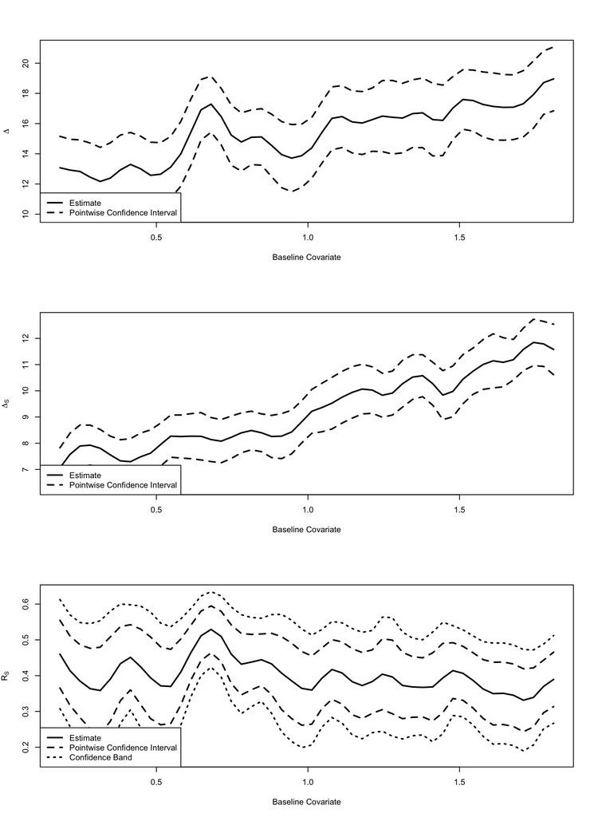

```r
# Plot estimates to visualize heterogeneity
hetsurr.plot(het.ob)
```

```r
# To save the high resolution plot directly to a file
# called plot.png.
png("plot.png", width = 8, height = 11, units = "in", res = 300)
hetsurr.plot(het.ob)
dev.off()
```

```r
# asking for tests for heterogeneity
set.seed(5)
het.ob = hetsurr.fun(y1 = example.data$y1, y0 = example.data$y0,
    s1 = example.data$s1, s0 = example.data$s0, w1 = example.data$w1,
    w0 = example.data$w0, test = TRUE)

# values returned in het.ob, now with testing results
names(het.ob)
```

```
##  [1] "w.values"               "delta.w"                "delta.w.s"
##  [4] "R.w.s"                  "se.delta.w"             "se.delta.w.s"
##  [7] "se.R.w.s"               "conf.delta.w.lower"     "conf.delta.w.upper"
## [10] "conf.delta.w.s.lower"   "conf.delta.w.s.upper"   "conf.R.w.s.lower"
## [13] "conf.R.w.s.upper"       "band.R.w.s.lower"       "band.R.w.s.upper"
## [16] "omnibus.test.statistic" "omnibus.p.value"        "trend.test.statistic"
## [19] "trend.p.value"
```

```r
het.ob$omnibus.p.value
```

```
## [1] 0.018
```

# Surrogate Evaluation from a Prediction Perspective (Section 4.5)

This code examines the PTE of a surrogate from a prediction perspective using the **pte_cont** function in the **OptimalSurrogate** package.

```r
# load the R package
library(OptimalSurrogate)

# take a look at the data
data(marker_cont)
names(marker_cont)
```

```
## [1] "sob" "yob" "aob"
```

```r
# flip so that higher values of Y are better
marker_cont_tutorial = marker_cont
marker_cont_tutorial$yob = -1 * marker_cont$yob

# Estimate the optimal transformation of S and the PTE of
# the optimal transformation
set.seed(5)
out = pte_cont(sob = marker_cont_tutorial$sob, yob = marker_cont_tutorial$yob,
    aob = marker_cont_tutorial$aob, var = TRUE, conf.int = TRUE)

# take a look at estimates
out$Estimates
```

```
##                est         se     lower     upper
## delta    0.2412751 0.03042336 0.1816453 0.3009049
## delta.gs 0.1597523 0.02030530 0.1199539 0.1995507
## pte1     0.6621168 0.05654075 0.5512969 0.7729367
## pte2     0.4927234 0.02711679 0.4395745 0.5458723
```

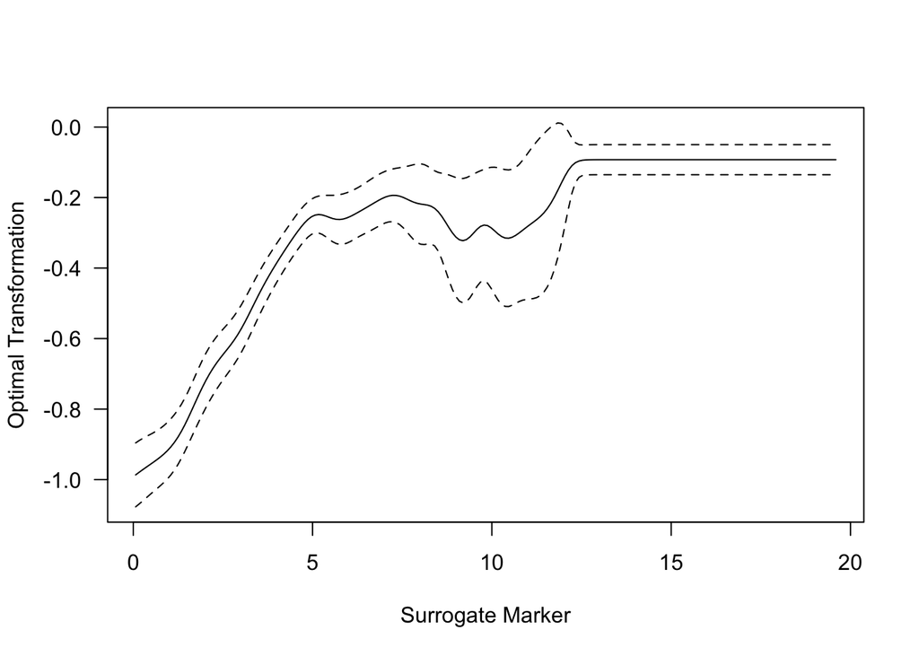

```r
# visualize the transformed surrogate
x = as.numeric(rownames(out$Transformed.S))
plot(x, out$Transformed.S[, "est"], ylim = range(out$Transformed.S[,
    -2]), type = "l", las = 1, xlab = "Surrogate Marker", ylab = "Optimal Transformation")
lines(x, out$Transformed.S[, "lower"], lty = 2)
lines(x, out$Transformed.S[, "upper"], lty = 2)
```

# Surrogate Paradox (Section 4.6)

This code tests the three sufficient conditions to protect against the surrogate paradox using the **test_assumptions** function in the **SurrogateParadoxTest** package.

```r
# load package
library(SurrogateParadoxTest)

# test assumptions
set.seed(5)
test_assumptions(s0 = d_example$s0.a, y0 = d_example$y0, s1 = d_example$s1.a,
    y1 = d_example$y1, all_results = FALSE, monotonicity_bootstrap_n = 5,
    nnr_bootstrap_n = 5)
```

```
##   Assumption                               Result
## 1 "Stochastic dominance assumption"        "Holds"
## 2 "Monotonicity assumption (control)"      "Holds"
## 3 "Monotonicity assumption (treatment)"    "Holds"
## 4 "Non-negative residual treatment effect" "Holds"
```

You’ve reached the end of the tutorial. Again, if you have any trouble with this code, file, or packages, or have any questions, please email me at parast@austin.utexas.edu.